# FE8828 Assignment for Exploratory Data Analysis

QU Mengyuan <sub><Email:QUME0001@e.ntu.edu.sg></sub>

Oct 2019

# Finding 1

This data contains 4521 rows and 17 columns.

# Finding 2

Most people are between 30 ans 39 years old.

```r
# Find the big age group
bank %>%
group_by(age_group = (age %/% 10) * 10) %>%
summarise(count = n()) %>%
arrange(age_group) -> res
res
```

```
## # A tibble: 8 x 2
##   age_group count
##       <dbl> <int>
## 1        10     4
## 2        20   478
## 3        30  1808
## 4        40  1203
## 5        50   854
## 6        60   113
## 7        70    47
## 8        80    14
```

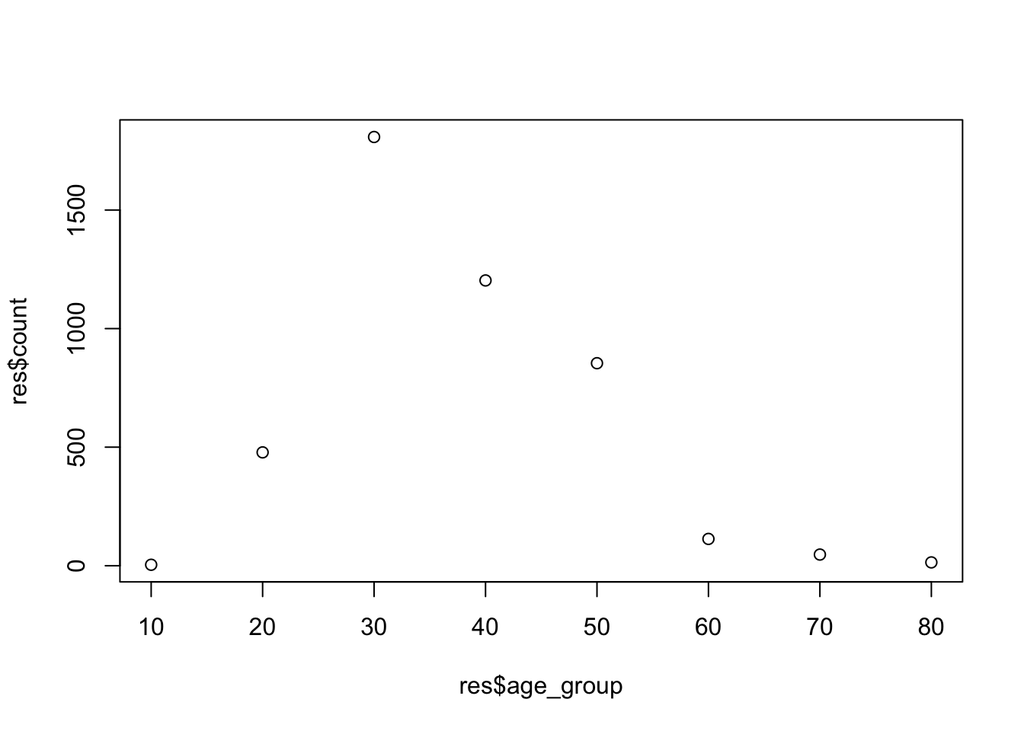

```r
plot(res$age_group, res$count)
```

# Finding 3

The average yearly balance varies among jobs.

The **retired** owns the *most* average yearly balance, with median equaling to *£672*.

People engaged in **services** owns the *least* average yearly balance, with median equaling to *£288*.

```r
# Find the relationship between job and balance
bank %>%
group_by(job) %>%
summarise(max = max(balance),min = min(balance),median = median(balance)) %>%
arrange(job) -> res
res
```

```
## # A tibble: 12 x 4
##    job             max   min median
##    <fct>         <int> <int>  <dbl>
##  1 admin.        22171  -967   430
##  2 blue-collar   16353 -1400   408.
##  3 entrepreneur  42045 -2082   366.
##  4 housemaid     26965  -759   296.
##  5 management    27359 -1746   577
##  6 retired       71188 -1206   672.
##  7 self-employed 16430 -3313   483
##  8 services      26394 -1202   288
##  9 student       11555  -230   422.
## 10 technician    27733 -1680   434.
## 11 unemployed     9019  -872   474.
## 12 unknown        7337     0   656.
```

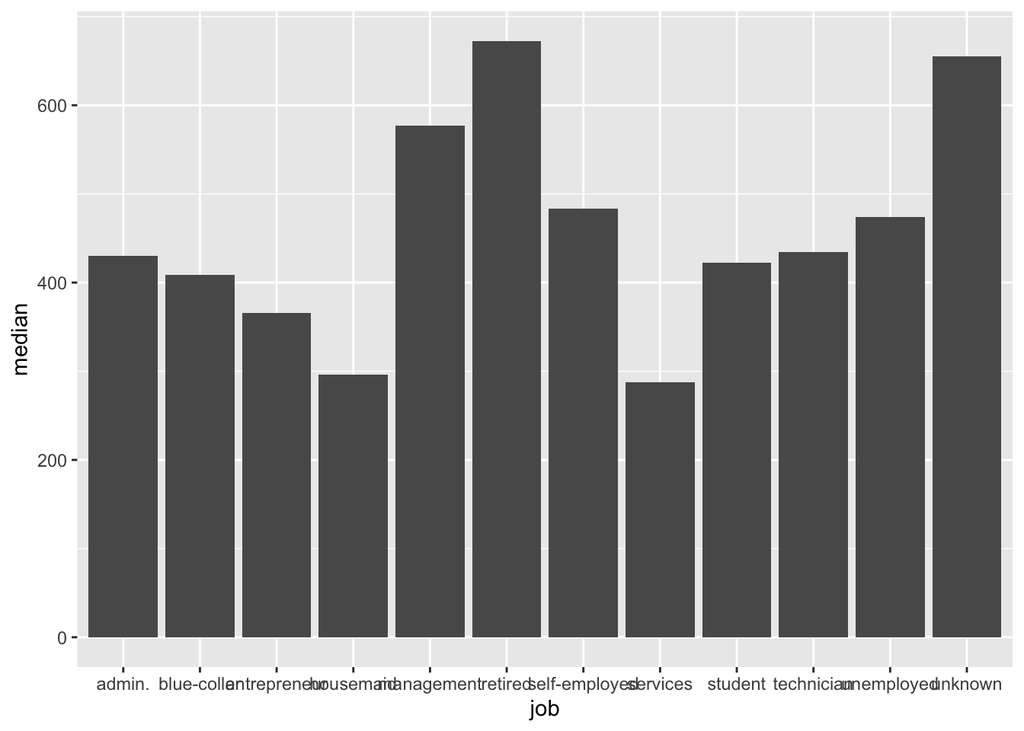

```r
ggplot(res, aes(job, median)) + geom_col()
```

# Finding 4

The marriage rate varies among jobs(excluding students and unknown).

The **entrepreneurs** has the *highest* marriage rate, equaling to *78.57%*.

The **technicians** has the *lowest* marriage rate, equaling to *53.52%*.

```r
# Find the relationship between job and marital
bank %>%
  dplyr::filter(marital=="married")  %>%
  group_by(job) %>%
  summarise(num = n()) -> res1
bank %>%
group_by(job) %>%
summarise(total = n()) -> res2
res <- full_join(res1,res2,by = "job")
res <- mutate(res, `marriage rate` = num/total)
res
```

```
## # A tibble: 12 x 4
##    job             num total `marriage rate`
##    <fct>         <int> <int>           <dbl>
##  1 admin.          266   478           0.556
##  2 blue-collar     693   946           0.733
##  3 entrepreneur    132   168           0.786
##  4 housemaid        84   112           0.75
##  5 management      557   969           0.575
##  6 retired         176   230           0.765
##  7 self-employed   127   183           0.694
##  8 services        236   417           0.566
##  9 student          10    84           0.119
## 10 technician      411   768           0.535
## 11 unemployed       75   128           0.586
## 12 unknown          30    38           0.789
```

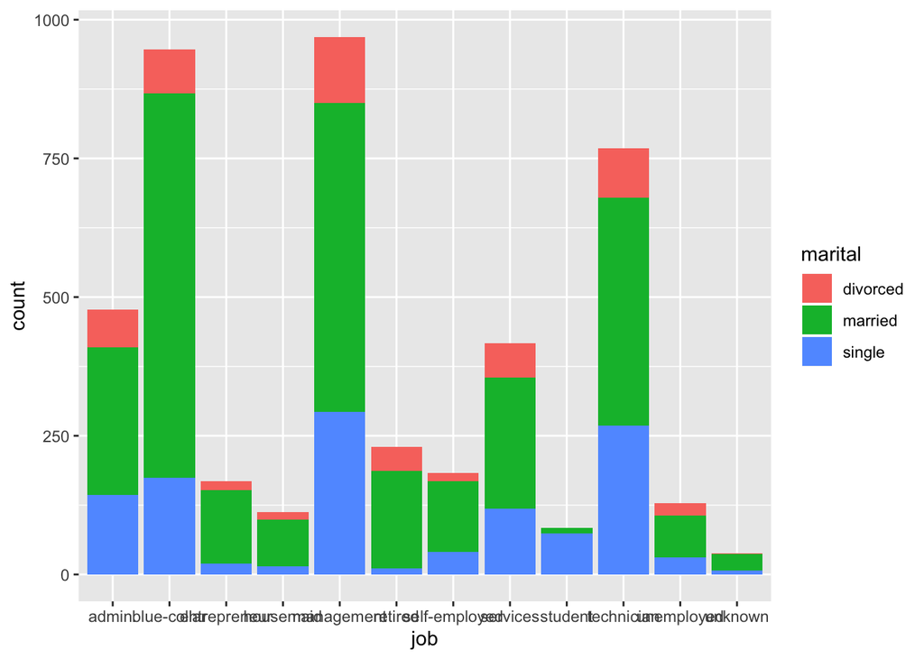

```r
ggplot() +
  geom_bar(data = bank, mapping = aes(x = job, fill = marital))
```

# Finding 5

The education level varies among age groups(excluding students).

```r
# Find the relationship between age and education
bank %>%
  dplyr::filter(education !="student")  %>%
  group_by(age_group = (age %/% 10) * 10, education) %>%
  summarise(num = n()) -> res
res
```

```
## # A tibble: 29 x 3
## # Groups:   age_group [8]
##    age_group education   num
##        <dbl> <fct>     <int>
##  1        10 primary       1
##  2        10 secondary     1
##  3        10 unknown       2
##  4        20 primary      25
##  5        20 secondary   301
##  6        20 tertiary    135
##  7        20 unknown      17
##  8        30 primary     158
##  9        30 secondary   948
## 10        30 tertiary    659
## # … with 19 more rows
```

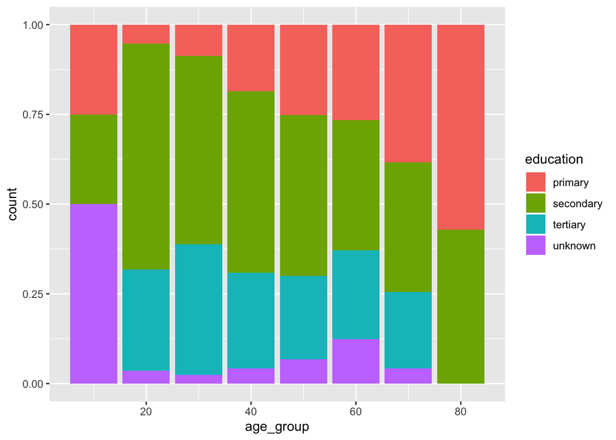

```r
bank <- bank %>% mutate(age_group = (age %/% 10) * 10)
ggplot() +
  geom_bar(data = dplyr::filter(bank, education !="student"), mapping = aes(x = age_group, fill = education), position = "fill")
```

# Finding 6 The education level varies among jobs(excluding students and unknown).

The **managers** has the *highest* education leve, more than 75% of which has tertiary education.

The **housemaids** has the **lowest** education leve, nearly half of whom only get primary education.

```r
# Find the relationship between job and education
bank %>%
group_by(job,education) %>%
summarise(num = n()) %>%
  spread(education, num) -> res
res
```

```
## # A tibble: 12 x 5
## # Groups:   job [12]
##    job           primary secondary tertiary unknown
##    <fct>           <int>     <int>    <int>   <int>
##  1 admin.             17       393       51      17
##  2 blue-collar       369       524       12      41
##  3 entrepreneur       26        58       73      11
##  4 housemaid          57        28       22       5
##  5 management         39       116      787      27
##  6 retired            80       105       31      14
##  7 self-employed      15        76       88       4
##  8 services           25       363       16      13
##  9 student             2        47       19      16
## 10 technician         15       520      211      22
## 11 unemployed         26        68       32       2
## 12 unknown             7         8        8      15
```

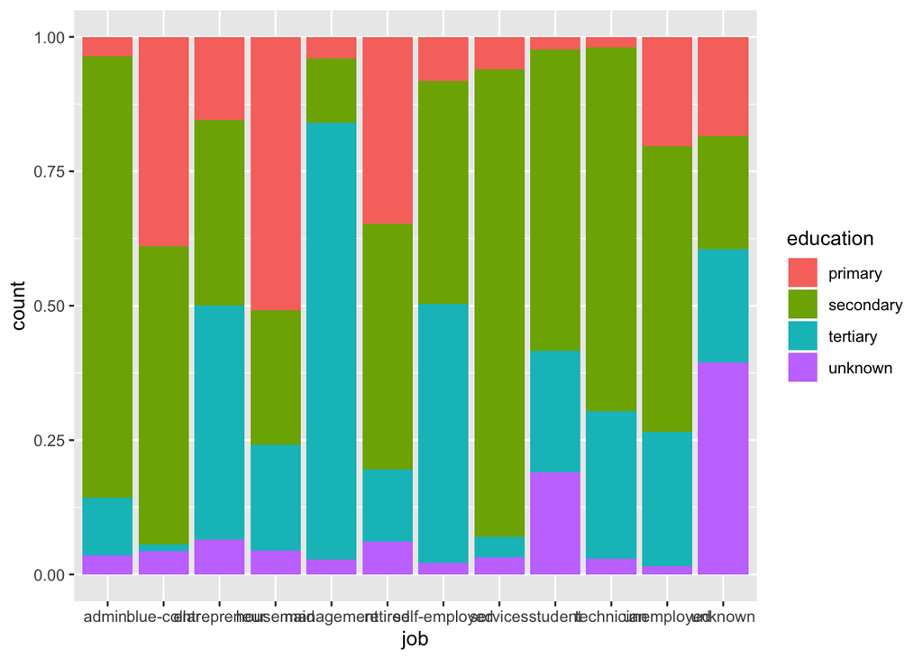

```r
ggplot() +
  geom_bar(data = bank, mapping = aes(x = job, fill = education),position = "fill")
```

# Finding 7 People who have personal loan have only around 55% of balance than those who don’t have personal loan. Housing loan has slight bad effects on people’s balance condition.

```r
# Find the relationship between balance and loans
bank %>%
group_by(housing,loan) %>%
  summarise(average = mean(balance), median = median(balance)) -> res
res
```

```
## # A tibble: 4 x 4
## # Groups:   housing [2]
##   housing loan  average median
##   <fct>   <fct>   <dbl>  <dbl>
## 1 no      no      1709.    502
## 2 no      yes      929.    276
## 3 yes     no      1362.    472
## 4 yes     yes      909.    278
```

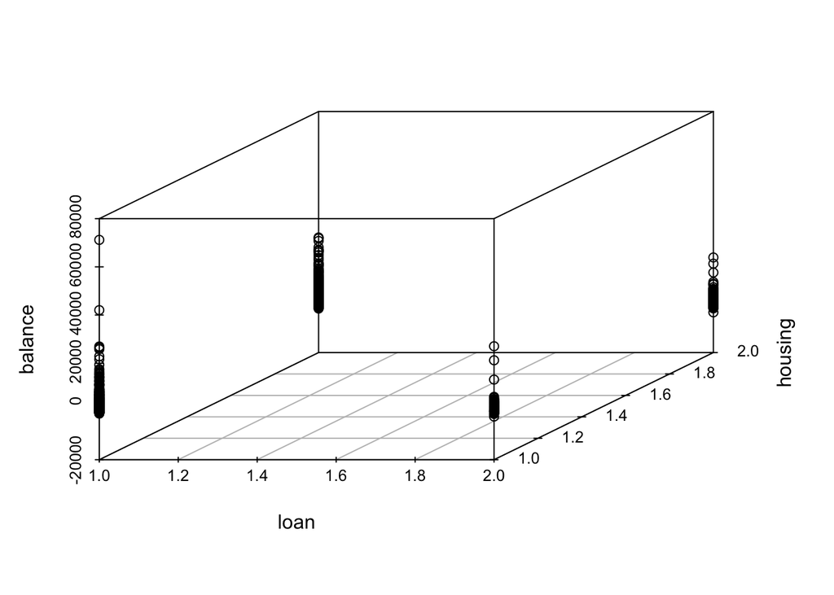

```r
library(scatterplot3d)
with(bank,{scatterplot3d(x = loan, y = housing, z = balance)})
```

# Finding 8

People who don’t have credit in default are in a **much better** balance condition compared with those who have credit in default, but have huge variation.

```r
# Find the relationship between default and balance
bank %>%
group_by(default) %>%
summarise(average = mean(balance), max = max(balance), min = min(balance), median = median(balance)) -> res
res
```

```
## # A tibble: 2 x 5
##   default average   max   min median
##   <fct>     <dbl> <int> <int>  <dbl>
## 1 no        1451. 71188 -1746    462
## 2 yes       -209.  1238 -3313    -19
```

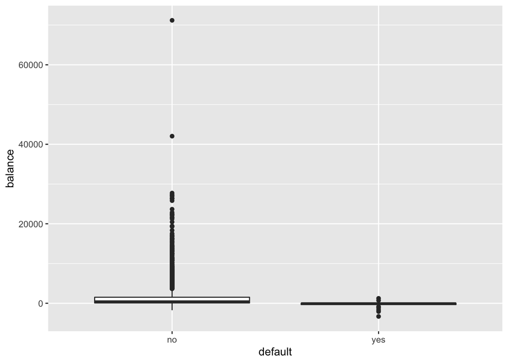

```r
ggplot(bank, aes(default, balance)) + geom_boxplot()
```

# Finding 9

The most common type of contact communication is by cellular.

The last contact durations of all three types concentrates around 175 seconds.

Generally, the last durations by *cellular* is the **longest** while that by *telephone* is the **shortest**.

```r
# Find the relationship between contact type and duration
bank %>%
group_by(contact) %>%
summarise(num = n(),average = mean(duration), max = max(duration), min = min(duration), median = median(duration)) -> res
res
```

```
## # A tibble: 3 x 6
##   contact     num average   max   min median
##   <fct>     <int>   <dbl> <int> <int>  <dbl>
## 1 cellular   2896    267.  3025     5   188
## 2 telephone   301    243.  1971     5   164
## 3 unknown    1324    262.  2769     4   184.
```

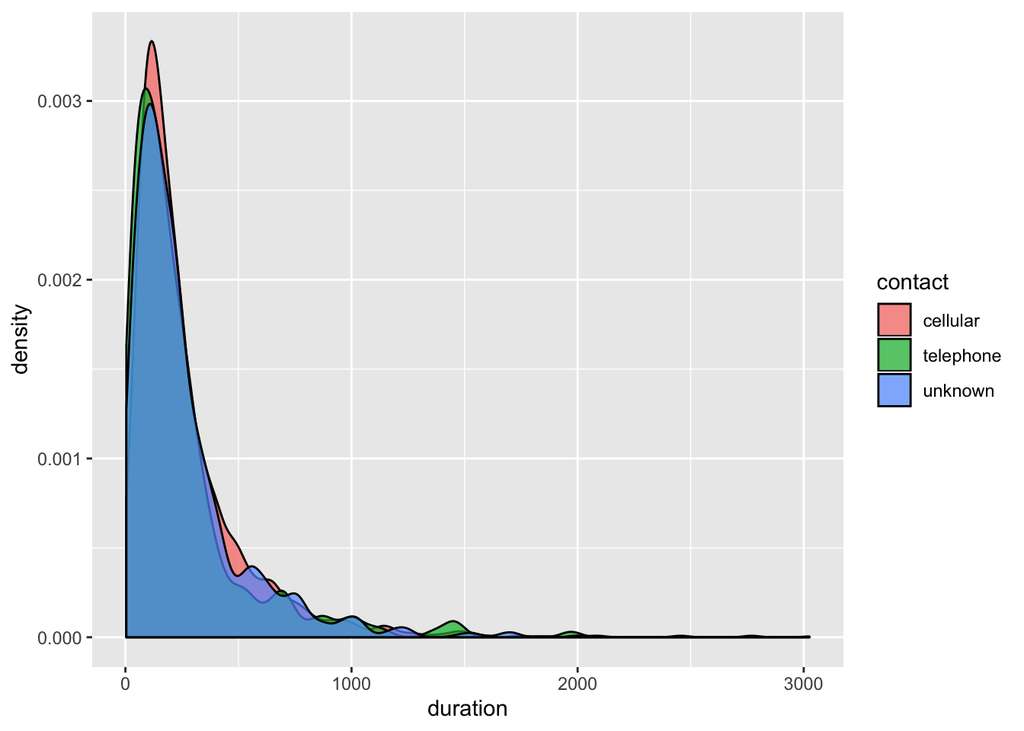

```r
ggplot(bank, aes(duration)) + geom_density(aes(fill = contact), alpha = 0.7)
```

# Finding 10

In the previous marketing campaign，most of people gets secondory and tertiary education.

```r
# outcome of the previous marketing campaign
bank %>%
  group_by(education, poutcome) %>%
  summarise(num = n()) %>%
  spread(poutcome, num)-> res
res
```

```
## # A tibble: 4 x 5
## # Groups:   education [4]
##   education failure other success unknown
##   <fct>       <int> <int>   <int>   <int>
## 1 primary        61    22      15     580
## 2 secondary     253   102      60    1891
## 3 tertiary      157    65      44    1084
## 4 unknown        19     8      10     150
```

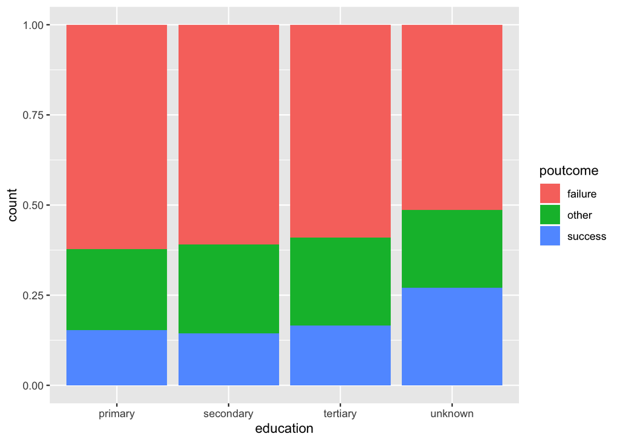

```r
ggplot() +
  geom_bar(data = dplyr::filter(bank, poutcome !="unknown"), mapping = aes(x = education, fill = poutcome),position = "fill")
```